# SA24204134_HW

# Hw_6

## Question 9.3

```r
answer_9_3 <- function(n, discard) {
  # 初始化：存储采样的向量，起始值为0
  samples <- numeric(n)
  samples[1] <- 0

  # Metropolis-Hastings采样过程
  for (i in 2:n) {
    # 生成候选值
    proposal <- samples[i - 1] + rnorm(1, mean = 0, sd = 1)
    # 计算接受比率
    acceptance_ratio <- dcauchy(proposal) / dcauchy(samples[i - 1])
    # 根据接受比率决定是否接受候选值
    if (runif(1) < acceptance_ratio) {
      samples[i] <- proposal
    } else {
      samples[i] <- samples[i - 1]
    }
  }

  # 丢弃前 discard 个样本，计算样本的分位数
  samples <- samples[(discard + 1):n]
  sample_deciles <- quantile(samples, probs = seq(0.1, 0.9, by = 0.1))
  theoretical_deciles <- qcauchy(seq(0.1, 0.9, by = 0.1))

  # 输出结果
  cat("Deciles of generated observations:\n", sample_deciles, "\n")
  cat("Deciles of standard Cauchy distribution:\n", theoretical_deciles, "\n")
}

# 设定随机种子并调用函数
set.seed(123)
answer_9_3(10000, 1000)
```

```
## Deciles of generated observations:
##  -2.817489 -1.402669 -0.7378453 -0.3335088 -0.01642563 0.3070602 0.7233017 1.372667 3.028368
## Deciles of standard Cauchy distribution:
##  -3.077684 -1.376382 -0.7265425 -0.3249197 0 0.3249197 0.7265425 1.376382 3.077684
```

## Question 9.8

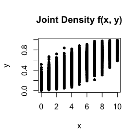

```r
answer_9_8 <- function(n, discard, a, b, n_val) {
  # 初始化：x 和 y 样本向量，设置初始值
  x_samples <- numeric(n)
  y_samples <- numeric(n)
  x_samples[1] <- 5
  y_samples[1] <- 0.5

  # Gibbs 采样过程
  for (i in 2:n) {
    # Step 1: 根据当前的 y 值更新 x 的条件分布：Binomial(n_val, y)
    y_current <- y_samples[i - 1]
    x_samples[i] <- rbinom(1, size = n_val, prob = y_current)

    # Step 2: 根据当前的 x 值更新 y 的条件分布：Beta(x + a, n_val - x + b)
    x_current <- x_samples[i]
    y_samples[i] <- rbeta(1, shape1 = x_current + a, shape2 = n_val - x_current + b)
  }

  # 丢弃前 discard 个样本，绘制后续的联合分布图
  plot(x_samples[(discard + 1):n], y_samples[(discard + 1):n],
       pch = 20, main = "Joint Density f(x, y)", xlab = "x", ylab = "y")
}

# 设置随机种子并调用函数
set.seed(123)
answer_9_8(10000, 1000, 2, 2, 10)
```

## Question

```r
converge_9_3 <- function(n, discard, n_chain) {
  # 初始化
  chains <- matrix(NA, nrow = n, ncol = n_chain)
  # 运行多条马尔可夫链
  for (j in 1:n_chain) {
    chain <- numeric(n)
    chain[1] <- 0
    for (i in 2:n) {
      proposal <- chain[i - 1] + rnorm(1, mean = 0, sd = 1)
      acceptance_ratio <- dcauchy(proposal) / dcauchy(chain[i - 1])
      if (runif(1) < acceptance_ratio) {
        chain[i] <- proposal
      } else { chain[i] <- chain[i - 1] }
    }
    chains[, j] <- chain
  }
  # 转换为mcmc.list对象
  mcmc_chains <- mcmc.list(lapply(1:n_chain, function(j) mcmc(chains[(discard + 1):n, j])))
  # Gelman-Rubin收敛诊断
  gelman_diag <- gelman.diag(mcmc_chains)$psrf[, "Point est."]
  cat("convergence of chains:", gelman_diag, "\n")
}
```

```r
converge_9_8 <- function(n, discard, a, b, n_val, n_chain) {
  # 初始化
  x_chains <- matrix(NA, nrow = n, ncol = n_chain)
  y_chains <- matrix(NA, nrow = n, ncol = n_chain)
  # 运行多条马尔可夫链
  for (j in 1:n_chain) {
    x_chain <- numeric(n)
    y_chain <- numeric(n)
    x_chain[1] <- 5
    y_chain[1] <- 0.5
    for (i in 2:n) {
      y_current <- y_chain[i - 1]
      x_chain[i] <- rbinom(1, size = n_val, prob = y_current)
      x_current <- x_chain[i]
      y_chain[i] <- rbeta(1, shape1 = x_current + a, shape2 = n_val - x_current + b)
    }
    x_chains[, j] <- x_chain
    y_chains[, j] <- y_chain
  }
  # 转换为mcmc.list对象
  x_mcmc_chains <- mcmc.list(lapply(1:n_chain, function(j) mcmc(x_chains[(discard + 1):n, j])))
  y_mcmc_chains <- mcmc.list(lapply(1:n_chain, function(j) mcmc(y_chains[(discard + 1):n, j])))
  # Gelman-Rubin收敛诊断
  gelman_diag_x <- gelman.diag(x_mcmc_chains)$psrf[, "Point est."]
  gelman_diag_y <- gelman.diag(y_mcmc_chains)$psrf[, "Point est."]
  cat("convergence of x_chains:", gelman_diag_x, "\n")
  cat("convergence of y_chains:", gelman_diag_y, "\n")
}
```

```r
library(coda)
set.seed(123)
converge_9_3(10000, 1000, 4)
```

```
## convergence of chains: 1.228299
```

```r
converge_9_8(10000, 1000, 2, 2, 10, 4)
```

```
## convergence of x_chains: 1.000392
## convergence of y_chains: 1.000514
```

# Hw_7

## Question 11.3

```r
answer_11_3 <- function(a, d, max_k) {
  # 计算第 k 项
  compute_term <- function(a, d, k) {
    norm_a <- sqrt(sum(a^2))  # 向量 a 的范数
    term <- ((-1)^k / (factorial(k) * 2^k)) *
            (norm_a^(2 * k + 2) / ((2 * k + 1) * (2 * k + 2))) *
            (gamma((d + 1) / 2) * gamma(k + 3 / 2) / gamma(k + d / 2 + 1))
    return(term)
  }

  # 计算和返回总和
  compute_sum <- function(a, d, max_k) {
    # 使用 sapply 计算所有项并求和
    summation <- sum(sapply(0:max_k, compute_term, a = a, d = d))
    return(summation)
  }

  # 输出结果
  result <- compute_sum(a, d, max_k)
  cat("The sum when a =", toString(a), "is:", result, "\n")
}

# 调用函数
answer_11_3(c(1, 2), 2, 10)
```

```
## The sum when a = 1, 2 is: 1.532165
```

```r
## Question 11.5
```

```r
answer_11_5 <- function(k_values) {
  # function of the integral
  ratio <- function(k) {
    return(2 * gamma((k + 1) / 2) / (sqrt(pi * k) * gamma(k / 2)))
  }
  ck <- function(a, k) {
    return(sqrt((a^2 * k) / (k + 1 - a^2)))
  }
  integral_left <- function(a, k) {
    result <- integrate(function(u) (1 + u^2 / (k - 1))^(-k / 2), lower = 0, upper = ck(a, k - 1))
    return(result$value)
  }
  integral_right <- function(a, k) {
    result <- integrate(function(u) (1 + u^2 / k)^(-(k + 1) / 2), lower = 0, upper = ck(a, k))
    return(result$value)
  }
  # solve the equation for a
  find_a <- function(k) {
    f <- function(a) {
      left_term <- ratio(k - 1) * integral_left(a, k)
      right_term <- ratio(k) * integral_right(a, k)
      return(abs(left_term - right_term))
    }
    solution <- optimize(f, interval = c(0.01, sqrt(k)))$minimum
    return(solution)
  }
  # 输出结果
  a_values <- sapply(k_values, find_a)
  print(data.frame(k = k_values, a = a_values))
}
```

```r
answer_11_5(c(4, 6, 8, 10))
```

```
##    k        a
## 1  4 1.492084
## 2  6 1.562754
## 3  8 1.601170
## 4 10 3.162223
```

由t分布的pdf有11.4 Sk-1(a)、Sk(a)相交等价于11.5 equation成立，a是A(k)的横坐标

## Question

```r
em_algo <- function(epsilon, max_iter) {
  Y <- c(0.54, 0.48, 0.33, 0.43, 1.00, 1.00, 0.91, 1.00, 0.21, 0.85)
  tau <- 1
  lambda <- 1
  for (iter in 1:max_iter) {
    # E-step
    uncensor <- Y[Y < tau]
    censor <- Y[Y == tau]
    n_uncensor <- length(uncensor)
    n_censor <- length(censor)
    E_T_censor <- tau + 1 / lambda
    # M-step
    lambda_iter <- (n_uncensor + n_censor) / (sum(uncensor) + n_censor * E_T_censor)
    if (abs(lambda_iter - lambda) < epsilon) {
      lambda <- lambda_iter
      break }
    lambda <- lambda_iter
  }
  # 输出结果
  cat("the E-M algorithm to estimate λ:", lambda, "\n")
  cat("the observed data MLE:", 1 / mean(Y), "\n")
}
```

```r
em_algo(1e-6, 100)
```

```
## the E-M algorithm to estimate λ: 1.037037
## the observed data MLE: 1.481481
```

# Hw_8

## 11.7

```r
# 加载 lpSolve 包
if (!require(lpSolve)) install.packages("lpSolve")
library(lpSolve)

# 定义目标函数系数 (c)
objective <- c(4, 2, 9)

# 定义约束矩阵 A
constraints <- matrix(c(
  2, 1, 1,  # 2x + y + z
  1, -1, 3  # x - y + 3z
), nrow = 2, byrow = TRUE)

# 定义右侧常数 b
rhs <- c(2, 3)

# 定义约束类型 (<=)
constraint_directions <- c("<=", "<=")

# 使用 lpSolve 进行优化
result <- lp(
  direction = "min",        # 最小化问题
  objective.in = objective, # 目标函数
  const.mat = constraints,  # 约束矩阵
  const.dir = constraint_directions, # 约束方向
  const.rhs = rhs           # 右侧常数
)

# 提取结果
solution <- result$solution
optimal_value <- result$objval

# 打印最优解和目标值
solution
```

```
## [1] 0 0 0
```

```r
optimal_value
```

```
## [1] 0
```

## exercise 3

```r
# 定义公式列表
formulas <- list(
  mpg ~ disp,
  mpg ~ I(1 / disp),
  mpg ~ disp + wt,
  mpg ~ I(1 / disp) + wt
)

# 使用 for 循环拟合模型
models_for <- list()
for (i in seq_along(formulas)) {
  models_for[[i]] <- lm(formulas[[i]], data = mtcars)
}

# 使用 lapply() 拟合模型
models_lapply <- lapply(formulas, function(f) lm(f, data = mtcars))

# 输出结果
models_for
```

```
## [[1]]
##
## Call:
## lm(formula = formulas[[i]], data = mtcars)
##
## Coefficients:
## (Intercept)         disp
##    29.59985     -0.04122
##
##
## [[2]]
##
## Call:
## lm(formula = formulas[[i]], data = mtcars)
##
## Coefficients:
## (Intercept)    I(1/disp)
##       10.75      1557.67
##
##
## [[3]]
##
## Call:
## lm(formula = formulas[[i]], data = mtcars)
##
## Coefficients:
## (Intercept)         disp           wt
##    34.96055     -0.01772     -3.35083
##
##
## [[4]]
##
## Call:
## lm(formula = formulas[[i]], data = mtcars)
##
## Coefficients:
## (Intercept)    I(1/disp)           wt
##      19.024     1142.560       -1.798
```

```r
models_lapply
```

```
## [[1]]
##
## Call:
## lm(formula = f, data = mtcars)
##
## Coefficients:
## (Intercept)         disp
##    29.59985     -0.04122
##
##
## [[2]]
##
## Call:
## lm(formula = f, data = mtcars)
##
## Coefficients:
## (Intercept)    I(1/disp)
##       10.75      1557.67
##
##
## [[3]]
##
## Call:
## lm(formula = f, data = mtcars)
##
## Coefficients:
## (Intercept)         disp           wt
##    34.96055     -0.01772     -3.35083
##
##
## [[4]]
##
## Call:
## lm(formula = f, data = mtcars)
##
## Coefficients:
## (Intercept)    I(1/disp)           wt
##      19.024     1142.560       -1.798
```

## exercise 4

```r
# 创建 bootstrap 样本列表
bootstrap_samples <- lapply(1:10, function(i) {
  rows <- sample(1:nrow(mtcars), replace = TRUE)
  mtcars[rows, ]
})

# 定义一个函数来拟合模型
fit_model <- function(data) {
  lm(mpg ~ disp, data = data)
}

# 使用 for 循环拟合模型
bootstrap_models_for <- list()
for (i in seq_along(bootstrap_samples)) {
  bootstrap_models_for[[i]] <- fit_model(bootstrap_samples[[i]])
}

# 使用 lapply() 拟合模型
bootstrap_models_lapply <- lapply(bootstrap_samples, fit_model)

# 输出结果
bootstrap_models_for
```

```
## [[1]]
##
## Call:
## lm(formula = mpg ~ disp, data = data)
##
## Coefficients:
## (Intercept)         disp
##    29.34215     -0.03968
##
##
## [[2]]
##
## Call:
## lm(formula = mpg ~ disp, data = data)
##
## Coefficients:
## (Intercept)         disp
##    27.04403     -0.03374
##
##
## [[3]]
##
## Call:
## lm(formula = mpg ~ disp, data = data)
##
## Coefficients:
## (Intercept)         disp
##    29.74188     -0.04483
##
##
## [[4]]
##
## Call:
## lm(formula = mpg ~ disp, data = data)
##
## Coefficients:
## (Intercept)         disp
##    29.28077     -0.04595
##
##
```

[output cut: 43 more lines]

```
## lm(formula = mpg ~ disp, data = data)
##
## Coefficients:
## (Intercept)         disp
##    29.75657     -0.04234
##
##
## [[10]]
##
## Call:
## lm(formula = mpg ~ disp, data = data)
##
## Coefficients:
## (Intercept)         disp
##    29.07826     -0.03986
```

```r
bootstrap_models_lapply
```

```
## [[1]]
##
## Call:
## lm(formula = mpg ~ disp, data = data)
##
## Coefficients:
## (Intercept)         disp
##    29.34215     -0.03968
##
##
## [[2]]
##
## Call:
## lm(formula = mpg ~ disp, data = data)
##
## Coefficients:
## (Intercept)         disp
##    27.04403     -0.03374
##
##
## [[3]]
##
## Call:
## lm(formula = mpg ~ disp, data = data)
##
## Coefficients:
## (Intercept)         disp
##    29.74188     -0.04483
##
##
## [[4]]
##
## Call:
## lm(formula = mpg ~ disp, data = data)
##
## Coefficients:
## (Intercept)         disp
##    29.28077     -0.04595
##
##
```

[output cut: 43 more lines]

```
## lm(formula = mpg ~ disp, data = data)
##
## Coefficients:
## (Intercept)         disp
##    29.75657     -0.04234
##
##
## [[10]]
##
## Call:
## lm(formula = mpg ~ disp, data = data)
##
## Coefficients:
## (Intercept)         disp
##    29.07826     -0.03986
```

## exercise 5

```r
# 定义提取 R^2 的函数
rsq <- function(mod) summary(mod)$r.squared

# 提取问题 3 中的模型的 R^2
r_squared_for <- sapply(models_for, rsq)
r_squared_lapply <- sapply(models_lapply, rsq)

# 提取问题 4 中的 bootstrap 模型的 R^2
r_squared_bootstrap_for <- sapply(bootstrap_models_for, rsq)
r_squared_bootstrap_lapply <- sapply(bootstrap_models_lapply, rsq)

# 输出 R^2 值
r_squared_for
```

```
## [1] 0.7183433 0.8596865 0.7809306 0.8838038
```

```r
r_squared_lapply
```

```
## [1] 0.7183433 0.8596865 0.7809306 0.8838038
```

```r
r_squared_bootstrap_for
```

```
##  [1] 0.6859031 0.7019242 0.8115721 0.7722901 0.7249998 0.5757130 0.7925343
##  [8] 0.6848205 0.8078835 0.6444520
```

```r
r_squared_bootstrap_lapply
```

```
##  [1] 0.6859031 0.7019242 0.8115721 0.7722901 0.7249998 0.5757130 0.7925343
##  [8] 0.6848205 0.8078835 0.6444520
```

## exercise 3

```r
# 模拟 t 检验的 100 次试验
set.seed(123) # 设置随机种子以保证结果可复现
trials <- replicate(
  100,
  t.test(rpois(10, 10), rpois(7, 10)),
  simplify = FALSE
)

# 查看 trials 的前几个结果
head(trials)
```

```
## [[1]]
##
##  Welch Two Sample t-test
##
## data:  rpois(10, 10) and rpois(7, 10)
## t = 0.023868, df = 12.91, p-value = 0.9813
## alternative hypothesis: true difference in means is not equal to 0
## 95 percent confidence interval:
##  -3.838986  3.924701
## sample estimates:
## mean of x mean of y
##  9.900000  9.857143
##
##
## [[2]]
##
##  Welch Two Sample t-test
##
## data:  rpois(10, 10) and rpois(7, 10)
## t = -6.7246, df = 12.661, p-value = 1.619e-05
## alternative hypothesis: true difference in means is not equal to 0
## 95 percent confidence interval:
##  -6.081856 -3.118144
## sample estimates:
## mean of x mean of y
##       6.4      11.0
##
##
## [[3]]
##
##  Welch Two Sample t-test
##
## data:  rpois(10, 10) and rpois(7, 10)
## t = -0.50537, df = 10.035, p-value = 0.6242
## alternative hypothesis: true difference in means is not equal to 0
## 95 percent confidence interval:
##  -3.784799  2.384799
## sample estimates:
## mean of x mean of y
##       9.3      10.0
```

[output cut: 27 more lines]

```
##  10.00000  10.57143
##
##
## [[6]]
##
##  Welch Two Sample t-test
##
## data:  rpois(10, 10) and rpois(7, 10)
## t = 0.44797, df = 13.904, p-value = 0.6611
## alternative hypothesis: true difference in means is not equal to 0
## 95 percent confidence interval:
##  -2.761909  4.219052
## sample estimates:
## mean of x mean of y
##  11.30000  10.57143
```

```r
# 使用匿名函数提取 p 值
p_values_anonymous <- sapply(trials, function(x) x$p.value)

# 查看前几个 p 值
head(p_values_anonymous)
```

```
## [1] 9.813226e-01 1.619096e-05 6.242135e-01 6.693526e-01 5.677105e-01
## [6] 6.610740e-01
```

```r
# 使用 [[ 直接提取 p 值
p_values_direct <- sapply(trials, `[[`, "p.value")

# 查看前几个 p 值
head(p_values_direct)
```

```
## [1] 9.813226e-01 1.619096e-05 6.242135e-01 6.693526e-01 5.677105e-01
## [6] 6.610740e-01
```

```r
# 验证两种方法是否一致
all.equal(p_values_anonymous, p_values_direct)
```

```
## [1] TRUE
```

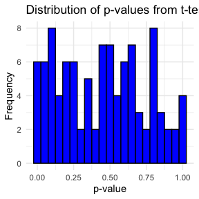

```r
# 加载 ggplot2 包
if (!require(ggplot2)) install.packages("ggplot2")
library(ggplot2)

# 创建 p 值数据框
p_values_df <- data.frame(p_value = p_values_direct)

# 绘制 p 值分布直方图
ggplot(p_values_df, aes(x = p_value)) +
  geom_histogram(binwidth = 0.05, fill = "blue", color = "black") +
  labs(
    title = "Distribution of p-values from t-tests",
    x = "p-value",
    y = "Frequency"
  ) +
  theme_minimal()
```

## exercise 4

```r
# 定义快速卡方统计量计算函数
fast_chisq <- function(x, y) {
  # 检查输入是否为数值向量且无缺失值
  stopifnot(is.numeric(x), is.numeric(y), !anyNA(x), !anyNA(y))

  # 创建联合频率表
  observed <- table(x, y)

  # 计算行和、列和和总和
  row_sums <- rowSums(observed)
  col_sums <- colSums(observed)
  total <- sum(observed)

  # 计算期望频数
  expected <- outer(row_sums, col_sums) / total

  # 计算卡方统计量
  chisq_stat <- sum((observed - expected)^2 / expected)

  return(chisq_stat)
}
```

```r
# 定义快速 table 函数
fast_table <- function(x, y) {
  # 检查输入是否为整数向量且无缺失值
  stopifnot(is.integer(x), is.integer(y), !anyNA(x), !anyNA(y))

  # 获取 x 和 y 的取值范围
  x_levels <- sort(unique(x))
  y_levels <- sort(unique(y))

  # 初始化频数矩阵
  freq_table <- matrix(0, nrow = length(x_levels), ncol = length(y_levels),
                       dimnames = list(x_levels, y_levels))

  # 填充频数矩阵
  for (i in seq_along(x)) {
    freq_table[as.character(x[i]), as.character(y[i])] <-
      freq_table[as.character(x[i]), as.character(y[i])] + 1
  }

  return(freq_table)
}
```

```r
# 定义结合快速 table 的卡方统计量计算
fast_chisq_with_table <- function(x, y) {
  # 检查输入是否为整数向量且无缺失值
  stopifnot(is.integer(x), is.integer(y), !anyNA(x), !anyNA(y))

  # 使用 fast_table 生成频率表
  observed <- fast_table(x, y)

  # 计算行和、列和和总和
  row_sums <- rowSums(observed)
  col_sums <- colSums(observed)
  total <- sum(observed)

  # 计算期望频数
  expected <- outer(row_sums, col_sums) / total

  # 计算卡方统计量
  chisq_stat <- sum((observed - expected)^2 / expected)

  return(chisq_stat)
}
```

```r
# 生成随机数据
set.seed(123)
x <- sample(1:5, 1000, replace = TRUE)
y <- sample(1:5, 1000, replace = TRUE)

# 比较性能
system.time({
  chisq_test_stat <- chisq.test(x, y)$statistic
})
```

```
##    user  system elapsed
##       0       0       0
```

```r
system.time({
  fast_stat <- fast_chisq(x, y)
})
```

```
##    user  system elapsed
##       0       0       0
```

```r
system.time({
  fast_stat_table <- fast_chisq_with_table(as.integer(x), as.integer(y))
})
```

```
##    user  system elapsed
##   0.006   0.000   0.007
```

```r
# 验证结果一致性
all.equal(chisq_test_stat, fast_stat)
```

```
## [1] "names for target but not for current"
```

```r
all.equal(chisq_test_stat, fast_stat_table)
```

```
## [1] "names for target but not for current"
```

# Hw_9

[figure not shown]

```r
gibbs_sampler <- function(n, a, b, iter, x0, y0) {
  # 初始化变量
  x <- numeric(iter)
  y <- numeric(iter)
  x[1] <- x0
  y[1] <- y0

  for (t in 2:iter) {
    # 1. 给定 y，从 Binomial(n, y) 中采样 x
    x[t] <- rbinom(1, n, y[t-1])

    # 2. 给定 x，从 Beta(x + a, n - x + b) 中采样 y
    y[t] <- rbeta(1, x[t] + a, n - x[t] + b)
  }

  return(data.frame(x = x, y = y))
}

# 示例参数
n <- 10
a <- 2
b <- 3
iter <- 1000
x0 <- 5
y0 <- 0.5

# 运行采样
samples <- gibbs_sampler(n, a, b, iter, x0, y0)
plot(samples$x, samples$y, main = "Gibbs采样结果", xlab = "x", ylab = "y")
```

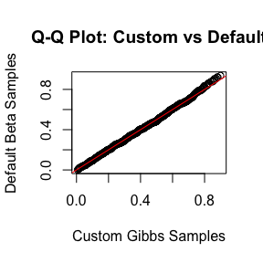

```r
# 加载必要包
library(ggplot2)
library(microbenchmark)

# 生成随机数
set.seed(123)
custom_samples <- gibbs_sampler(n, a, b, iter, x0, y0)$y  # 使用自定义函数生成
default_samples <- rbeta(iter, a, b)  # 使用默认Beta分布采样

# 绘制 Q-Q 图
qqplot(custom_samples, default_samples, main = "Q-Q Plot: Custom vs Default",
       xlab = "Custom Gibbs Samples", ylab = "Default Beta Samples")
abline(0, 1, col = "red")
```

```r
# 使用 microbenchmark 比较两种方法的速度
benchmark_results <- microbenchmark(
  custom = gibbs_sampler(n, a, b, iter, x0, y0),
  default = rbeta(iter, a, b),
  times = 100
)
# 打印基准测试结果
print(benchmark_results)
```

```
## Unit: microseconds
##     expr      min        lq       mean    median       uq      max neval
##   custom 1177.684 1198.2865 1257.11084 1215.8755 1303.636 3041.380   100
##  default   61.049   63.7755   66.01861   64.8005   65.969   87.002   100
```

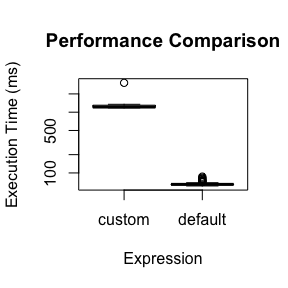

```r
# 可视化性能对比
boxplot(benchmark_results, main = "Performance Comparison",
        ylab = "Execution Time (ms)")
```

根据生成的 qqplot 和 microbenchmark 的输出，进行以下分析： 1. 分布相似性： • 如果 Q-Q 图接近对角线，说明两种方法生成的随机数分布接近。 • 如果偏离明显，可能存在实现差异，需要检查自定义函数。 2. 计算时间： • 如果自定义函数的运行时间显著高于默认方法，可以优化实现或使用内置方法。 • 如果性能相当，则自定义方法在特定情境下可能更灵活。